# Analysis of Publications in the INLPO

**Table 1.** Type and number of INL Project Office publications (1949–2022).

[**Type of publication**: the period of time over which they were published are enclosed within parentheses. **Count**: number of publications. **Percent**: is the percentage of the total number of publications. Note that percentages may not sum to 100 percent due to rounding.]

| Type of publication | Count | Percent |
| --- | --- | --- |
| Article from a journal (1963–2020) | 32 | 8.7 |
| Article in a conference proceedings (1962–2016) | 14 | 3.8 |
| Master’s thesis (1990–2018) | 14 | 3.8 |
| **U.S. Geological Survey** |  |  |
| Open-File Report (1953–2021) | 106 | 29.0 |
| Water-Resources Investigations Report (1979–2003) | 68 | 18.6 |
| Scientific Investigations Report (2005–2021) | 52 | 14.2 |
| Professional Paper (1964–2019) | 6 | 1.6 |
| Data Series (2008–2017) | 4 | 1.1 |
| Fact Sheet (1997–2017) | 4 | 1.1 |
| Circular (1982) | 2 | 0.5 |
| Software Release (2021–2022) | 2 | 0.5 |
| Bulletin (1964) | 1 | 0.3 |
| Geophysical Investigation Map (1964) | 1 | 0.3 |
| Miscellaneous Investigations Series Map (1994) | 1 | 0.3 |
| software release (2020) | 1 | 0.3 |
| Water Supply Paper (1982) | 1 | 0.3 |
| **U.S. Atomic Energy Commission** |  |  |
| Idaho Operations Office Publication (1949–1980) | 55 | 15.0 |
| **Idaho Geological Survey** |  |  |
| Technical Report (2020) | 1 | 0.3 |
| **Idaho Department of Water Administration** |  |  |
| Water Information Bulletin (1973) | 1 | 0.3 |
| Total | 366 |  |

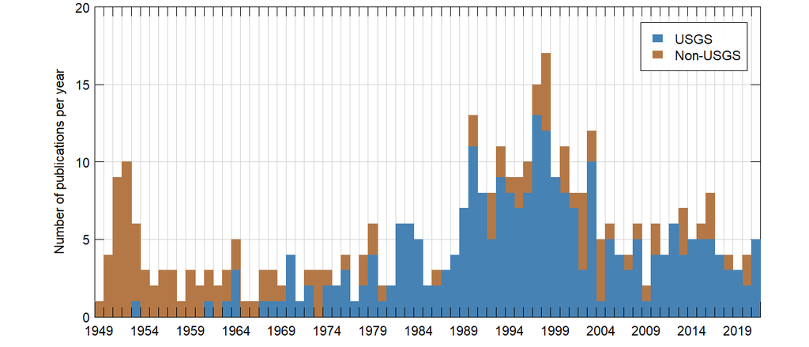

**Figure 1.** Distribution of INL Project Office publications (1949–2022). USGS and non-USGS publication types are distinguished by color.

A total of 2,278 unique words were identified in the titles and abstracts of INLPO publications. A frequency count of these words is provided in table 2 and sorted in order of decreasing frequency. Water is the most used word with a count of 1,255.

**Table 2.** The frequency of words used in titles and abstracts (1949–2022). Words with a frequency count of less than three were excluded from the table.

[**Word**: is a word taken from the unstructured text. **Frequency count**: is the number of appearances in the documents. **No. of publications**: is the number of documents containing the word.]

| Word | Frequency count | No. of publications |
| --- | --- | --- |
| water | 1255 | 219 |
| idaho | 1052 | 346 |
| concentrations | 762 | 122 |
| wells | 762 | 154 |
| aquifer | 665 | 176 |
| river | 611 | 234 |
| national | 584 | 308 |
| samples | 583 | 154 |
| laboratory | 549 | 259 |
| flow | 459 | 93 |

[output cut: 2268 more lines]